# Homework 4 W80

Austin Harnsberger

1/15/2015

```r
library(ISLR)
```

**4)**  
**A)** We will use 1/(number of available observations) of the observations to determine our prediction.  
**B)** We will use 2/(number of available observations) of the observations for our predictions.  
**C)** We use a very large fraction of the available observatations, 100/(number of available observations) to make our predictions.  
**D)** As p increases, the number of observations necessary for predictions increases, making the observer have to search further away from the test point to meet the quota of observations. As p increases the model for the KNN becomes more and more linear and rigid.  
**6)**  
**A)**

`r A = exp(-6+.05*40+3.5)/(1+exp(-6+.05*40+3.5)) A`

`## [1] 0.3775407` **B)** The student would need 50 hours minimum to have a 50% chance of getting an A with a 3.5 GPA.  
**9)**  
**A)** The fraction of people who default with odds of .37 is 21%  
**B)** The odds of a person defaulting with 16% chance are .23  
**10)** **A)**

`r names(Weekly)`

`## [1] "Year" "Lag1" "Lag2" "Lag3" "Lag4" "Lag5" ## [7] "Volume" "Today" "Direction"`

`r summary(Weekly)`

`## Year Lag1 Lag2 Lag3 ## Min. :1990 Min. :-18.1950 Min. :-18.1950 Min. :-18.1950 ## 1st Qu.:1995 1st Qu.: -1.1540 1st Qu.: -1.1540 1st Qu.: -1.1580 ## Median :2000 Median : 0.2410 Median : 0.2410 Median : 0.2410 ## Mean :2000 Mean : 0.1506 Mean : 0.1511 Mean : 0.1472 ## 3rd Qu.:2005 3rd Qu.: 1.4050 3rd Qu.: 1.4090 3rd Qu.: 1.4090 ## Max. :2010 Max. : 12.0260 Max. : 12.0260 Max. : 12.0260 ## Lag4 Lag5 Volume ## Min. :-18.1950 Min. :-18.1950 Min. :0.08747 ## 1st Qu.: -1.1580 1st Qu.: -1.1660 1st Qu.:0.33202 ## Median : 0.2380 Median : 0.2340 Median :1.00268 ## Mean : 0.1458 Mean : 0.1399 Mean :1.57462 ## 3rd Qu.: 1.4090 3rd Qu.: 1.4050 3rd Qu.:2.05373 ## Max. : 12.0260 Max. : 12.0260 Max. :9.32821 ## Today Direction ## Min. :-18.1950 Down:484 ## 1st Qu.: -1.1540 Up :605 ## Median : 0.2410 ## Mean : 0.1499 ## 3rd Qu.: 1.4050 ## Max. : 12.0260` Most of the means and medians are close together between columns and all but two of the 1st Qu. are negative.  
**B)** **12)**  
**A)**

`r Power = 2^3 print(Power)`

`## [1] 8` **B)**

`r Power2 = function(x,a){ Power2 = x^a print(Power2) }` **C)**

`r Power2(8,17)`

`## [1] 2.2518e+15`

`r Power2(131,3)`

`## [1] 2248091` **D)**

`r Power3 = function(x,a){ result = x^a return(result) }` **E)**

`r Power3 = function(x){ Power3 = x^2 plot(Power3) }` **F)**

`r Powerplot = function(x,a){ Powerplot = x^a plot(Powerplot) } Powerplot(1:10,2)`

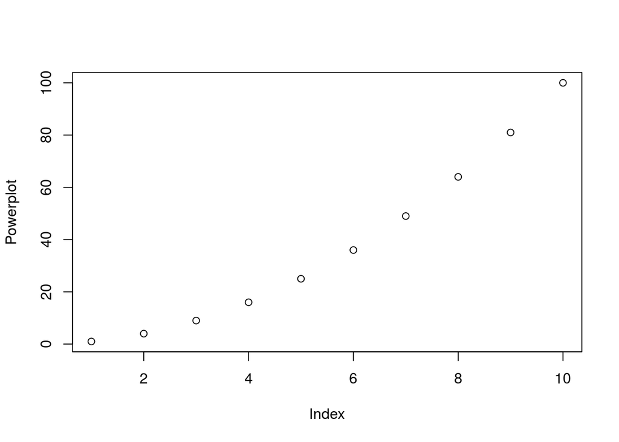